# Info 201 Project

# Introduction

### Give the context–why is this an interesting topic?

Investigating the relationship between COVID-19 vaccination rates and general vaccine trust across states is an intriguing topic that can have a significant impact on public health strategies. By understanding how trust in COVID-19 vaccines aligns with general vaccine confidence, we can gain valuable insights for tailoring communication efforts and targeted interventions. This topic is critical and timely as it addresses the broader issue of vaccine hesitancy, moving beyond immediate pandemic concerns to contribute to a more enduring aspect of public health - vaccine confidence.

This shift in focus is intriguing because it delves into the broader context of vaccine hesitancy and acceptance. Understanding whether there is a correlation between trust in the COVID-19 vaccine and general vaccine trust can provide insights into the underlying factors shaping public attitudes. It introduces a nuanced layer to the analysis, moving beyond the immediate pandemic concerns to address a more enduring aspect of public health - vaccine confidence.Investigating the relationship between COVID-19 vaccination rates and general vaccine trust across states is an intriguing topic that can have a significant impact on public health strategies. By understanding how trust in COVID-19 vaccines aligns with general vaccine confidence, we can gain valuable insights for tailoring communication efforts and targeted interventions. This topic is critical and timely as it addresses the broader issue of vaccine hesitancy, moving beyond immediate pandemic concerns to contribute to a more enduring aspect of public health - vaccine confidence.

This shift in focus is intriguing because it delves into the broader context of vaccine hesitancy and acceptance. Understanding whether there is a correlation between trust in the COVID-19 vaccine and general vaccine trust can provide insights into the underlying factors shaping public attitudes. It introduces a nuanced layer to the analysis, moving beyond the immediate pandemic concerns to address a more enduring aspect of public health - vaccine confidence.

### What do we already know about this topic? This should be based on what you read from media or literature, not on what you do below!

Various studies and reports have provided valuable insights into the complex dynamics of COVID-19 and influenza vaccine acceptance. For instance, reports published in The Lancet and JAMA Network Open have explored the factors that influence COVID-19 vaccine acceptance and hesitancy. These studies have revealed a complex interplay of demographics, socio-economic status, and geography. The CDC data on influenza vaccination coverage across different years shows how the acceptance of flu vaccine changes over time, influenced by public awareness initiatives, healthcare policies, and the severity of flu seasons. Media reports, such as those in Nature, have highlighted the range of public perceptions surrounding COVID-19 vaccines. These reports emphasize the challenges posed by vaccine misinformation. Similarly, analyses from Health Affairs and other sources have revealed geographic disparities in COVID-19 and influenza vaccination rates. These studies have emphasized the impact of access to healthcare and regional attitudes toward vaccines. The association between socio-economic factors and vaccination rates, as elucidated in JAMA Network Open, further contributes to our understanding of the intricate relationships that shape vaccine acceptance in communities. This background knowledge sets the stage for our exploration into the correlation between COVID-19 vaccination rates, general vaccine trust, and the broader socio-demographic and economic landscape.

### Explain what exactly you are doing. This can be stated as questions you want to answer, or some kind of stories you want to tell. There should be one question or one story line for each member of the group, so you need to have at least as many research questions as the group size. (This is about the number of tasks but not about who is responsible for which task.)

Are states with higher general vaccine trust more likely to have higher COVID-19 vaccination rates? It is a fascinating matter because the COVID-19 Vaccine had a lot of skepticism and mistrust regarding how effective and safe it would be to take a vaccine that was produced at a record speed in response to a worldwide pandemic. It is beneficial to find any correlation between a person’s previous history of accepting other vaccines and compare that to their willingness to take a vaccine that was created with a new technology that speeds up its development. It is crucial to understand why people are unwilling to accept brand-new advances and breakthroughs in vaccine technology. Being able to counteract this wave of misinformation, and skepticism would make the necessary advances in vaccine technology be accepted and trusted more smoothly.

Are there notable disparities in vaccination coverage that could indicate regional challenges or successes in vaccine distribution? Many areas throughout America have had great difficulty in accessing COVID-19 vaccines as a result of both shortages, the unique storage requirements of the vaccine, the 2-dose nature of the vaccine, as well as federal government priority. These challenges are unique to the COVID-19 vaccine as they come as a result of the rapid development of the vaccine in response to the pandemic. We need to be able to assess how much of an impact these challenges have had on the vaccination of people in America, and we can do so by comparing the administration of a generic vaccine such as the influenza vaccine to the COVID-19 vaccine.

Our research aims to investigate whether there is a correlation between the uptake of the influenza vaccine and the initial COVID-19 vaccination rates. To do this, we will analyze datasets from reliable sources such as the CDC and healthdata.gov to gather information on influenza vaccination coverage and COVID-19 vaccination rates across different states. We will use statistical analysis, specifically correlation analysis, to determine if there is a significant relationship between these two vaccination rates.

The main goal is to contribute nuanced insights into vaccine acceptance patterns. By exploring the correlation between influenza and COVID-19 vaccination rates, we aim to identify potential relationships and influencing factors. This analysis will not only enhance our understanding of vaccine acceptance dynamics but also provide valuable information for public health advocates and policymakers. The findings may aid in shaping targeted interventions and communication strategies, ultimately contributing to more effective public health measures.

### Explain why is it interesting–why should someone care? why should someone read your report?

Understanding the relationship between influenza and COVID-19 vaccination rates is important for gaining insights into broader patterns of vaccine acceptance and hesitancy. This knowledge is crucial not only for managing the ongoing COVID-19 pandemic but also for future public health initiatives. Identifying a correlation could provide a better understanding of the factors or attitudes that influence individuals’ decisions regarding different vaccines, leading to more comprehensive insights into vaccine acceptance dynamics.

The practical implications of this study’s findings are significant for public health advocates and policymakers. By recognizing disparities or correlations between influenza and COVID-19 vaccination rates, tailored interventions and communication strategies can be implemented for specific regions or demographic groups. Implementing a targeted approach is necessary for overcoming vaccine hesitancy, ensuring widespread vaccination coverage, and achieving herd immunity, which is essential for preventing the spread of infectious diseases.

Additionally, this study’s focus on the correlation between influenza and COVID-19 vaccination rates adds nuance to existing research. While previous studies have concentrated on individual vaccine types, this analysis considers the interplay between different vaccines, providing a more comprehensive perspective on public attitudes towards vaccination.

In summary, this research is essential for individuals, healthcare professionals, and policymakers as it has the potential to provide actionable insights that can inform public health strategies, improve vaccination outreach, and contribute to more effective pandemic response efforts. The findings may guide efforts to address vaccine hesitancy, enhance overall vaccine confidence, and ultimately lead to a healthier and more resilient population.

# Load libraries and data

Influenza vaccine data source: https://data.cdc.gov/Flu-Vaccinations/Influenza-Vaccination-Coverage-for-All-Ages-6-Mont/vh55-3he6 Covid vaccine data source: https://data.cdc.gov/Vaccinations/COVID-19-Vaccinations-in-the-United-States-County/8xkx-amqh

```r
library(tidyverse)
influenza_vaccine_data = read.csv("data/Influenza_data.csv")
#print(sample_n(influenza_vaccine_data,10))
covid_vaccine_data = read.csv("data/Covid_data.csv") # Note: the covid data is huge relative to the influenza data, so it might take some time to load
#print(sample_n(covid_vaccine_data,10))
```

# Data Cleaning

Filter out irrelevant geography types to get only the counties, clean up some other aspects. It is important to point out that this data is estimated based off of state data and population distribution, meaning the actual percentage of each county may not be accurate. Unfortunately, we do not have the same amount of precision as we do with the covid data as there were less resources dedicated to influenza. We are only focusing on 2019-2020 influenza data because we just need a snapshot of how willing people are to taking vaccines shortly before COVID-19.

This results in two dataframes: covid_vaccine_data_cleaned and influenza_vaccine_data_cleaned Both dataframe’s rows represent a unique county covid_vaccine_data_cleaned and influenza_vaccine_data_both both have two columns, FIPS (County Identifier), and a percentage of vaccination relative to population. Furthermore, covid_vaccine_data_cleaned contains two additional column, 2019 census data, for use in identifying outliers later, as well as date. All the influenza data is from 2019-2020.

```r
covid_vaccine_data_cleaned = covid_vaccine_data %>%
  select(FIPS, Administered_Dose1_Pop_Pct, Date, Census2019_18PlusPop) %>% # Remove unnecessary columns. We'll only look at dose1 in the two dose covid vaccine.
  #mutate(Recip_County = sub(" .*", "", Recip_County)) %>% # Remove the unnecessary "county" specification after every county name
  mutate(Date = as.Date(Date,format = "%m/%d/%Y")) %>% # Convert dates into a R friendly format
  filter(!is.na(as.numeric(FIPS))) %>% # Remove unique region-county identifiers
  rename(Covid_Percentage = Administered_Dose1_Pop_Pct) %>%
  mutate(FIPS = as.numeric(FIPS))
```

```r
# Note: This dataset has column names which haves spaces in them. When refering to these columns, enclose the column name with backticks (`). FIPS = County identifier (Since many counties have duplicate names).
influenza_vaccine_data_cleaned = influenza_vaccine_data %>%
  filter(Vaccine == "Seasonal Influenza") %>% # Only the general influenza vaccine will be considered as the special variants make up a negligible proportion
  filter(`Geography.Type` == "Counties") %>% # Filter out non-county data (state/local areas)
  filter(`Dimension.Type` == "Age") %>% # Filter out vaccine demographic data (data only includes people >=18)
  filter(!is.na(as.numeric(FIPS))) %>% # Remove unique region-county identifiers
  filter(`Season.Survey.Year` == "2019-20") %>% # Only keep 2019-2020 data for simplicity (may add more dates later)
  rename(Influenza_Percentage = `Estimate....`) %>%
  mutate(Influenza_Percentage = as.numeric(Influenza_Percentage)) %>%# Convert the estimate % from character to numeric
  #rename(Date = "Season/Survey Year")
  select(FIPS, Influenza_Percentage) # Filter out irrelevant columns

print(sample_n(influenza_vaccine_data_cleaned,10))
```

```
##     FIPS Influenza_Percentage
## 1  47101                 40.4
## 2   1117                 47.0
## 3  13011                 34.5
## 4  48145                 36.9
## 5  47157                 38.1
## 6  46053                 49.7
## 7  12073                 35.6
## 8  40087                 46.8
## 9  41015                 41.6
## 10 13139                 38.7
```

```r
print(sample_n(covid_vaccine_data_cleaned, 10))
```

```
##     FIPS Covid_Percentage       Date Census2019_18PlusPop
## 1  47137             40.7 2021-08-28                 4185
## 2  12097             93.5 2023-02-22               285151
## 3  35007              0.0 2021-03-21                 9803
## 4  13207              1.3 2021-02-09                21985
## 5  42099             57.0 2021-10-02                36410
## 6  54041             63.0 2022-04-08                12565
## 7  30081             46.5 2021-09-22                35591
## 8  20081             44.4 2022-05-17                 2859
## 9  13221             46.8 2022-02-22                12099
## 10 26011             53.6 2022-09-21                12193
```

# Merging dataframes

We employ an inner join to combine the influenza vaccine dataframes as well as various dates of the covid vaccination data. We chose one month, six months, and on year from the release of the covid_vaccine as we believed this would give us the most important and relevant dates when it comes to identifying covid vaccine acceptance relative to influenza vaccine acceptance in 2020.

```r
joinedData <- inner_join(influenza_vaccine_data_cleaned, covid_vaccine_data_cleaned, by = "FIPS")
#print(joinedData)

FirstMonth <- joinedData%>%
  select(Covid_Percentage, Date,FIPS, Census2019_18PlusPop )%>%
  filter(Date == "2021-01-17")%>%
  rename(fips = FIPS)

SixMonths <- joinedData %>%
  select(Covid_Percentage, Date,FIPS, Census2019_18PlusPop)%>%
  filter(Date ==  "2021-06-17")%>%
  rename(fips = FIPS)

OneYear <- joinedData %>%
  select(Covid_Percentage, Date,FIPS, Census2019_18PlusPop)%>%
  filter(Date == "2022-01-17")%>%
  rename(fips = FIPS)

influenza_vaccine_data_cleaned1 <- influenza_vaccine_data_cleaned%>%
  rename(fips = FIPS)

FirstMonthjoinedPlus <- inner_join(FirstMonth, influenza_vaccine_data_cleaned1, by = "fips" )
SixMonthsjoinedPlus <- inner_join(SixMonths, influenza_vaccine_data_cleaned1, by = "fips" )
oneYearjoinedPlus <- inner_join(OneYear, influenza_vaccine_data_cleaned1, by = "fips" )
print(sample_n(FirstMonthjoinedPlus,10))
```

```
##    Covid_Percentage       Date  fips Census2019_18PlusPop Influenza_Percentage
## 1               2.7 2021-01-17 29123                 9307                 45.2
## 2               0.0 2021-01-17 13011                14968                 34.5
## 3               3.4 2021-01-17 26009                19206                 45.7
## 4               0.0 2021-01-17 45005                 7033                 34.9
## 5               0.0 2021-01-17 51820                17265                 44.7
## 6               0.0 2021-01-17 55075                32737                 43.4
## 7               3.8 2021-01-17 47063                50013                 39.5
## 8               0.0 2021-01-17 28021                 7106                 35.3
## 9               0.0 2021-01-17 49019                 7655                 40.3
## 10              3.1 2021-01-17 22115                35749                 36.0
```

# Mapping Information

Maps of covid vaccine percentage by county across multiple dates, as well as influenza vaccine data in 2019-2020. This is simply to give a quick visual representation of the cleaned data before we attempt to analyze it.

```r
US_One_Month <- joinedData %>%
  select(FIPS, Covid_Percentage, Date)%>%
  filter(Date == "2021-01-17")%>%
  rename(fips = FIPS)

US_Six_Month <- joinedData %>%
  select(FIPS, Covid_Percentage, Date)%>%
  filter(Date ==  "2021-06-17")%>%
  rename(fips = FIPS)

US_One_Year <- joinedData %>%
  select(FIPS, Covid_Percentage, Date)%>%
  filter(Date == "2022-01-17")%>%
  rename(fips = FIPS)

library(usmap)
```

This is a map of the US counties and represents the percentage of how many people in each county who took the Influenza vaccine Pre covid 19 and for the most part it seems pretty even county to county.

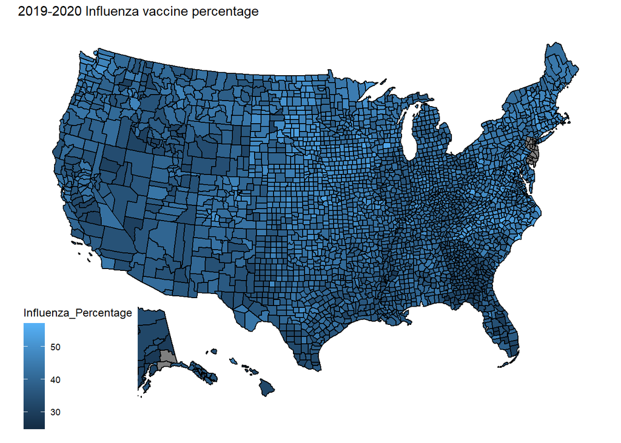

```r
plot_usmap(data = influenza_vaccine_data_cleaned1, values = "Influenza_Percentage", "counties", color="black")+
  labs(title = "2019-2020 Influenza vaccine percentage")
```

The first month into the covid 19 vaccine being released not many states or counties even had access to or allowed their citizens to take the covid 19 vaccine until it was later determined to be 100 percent safe

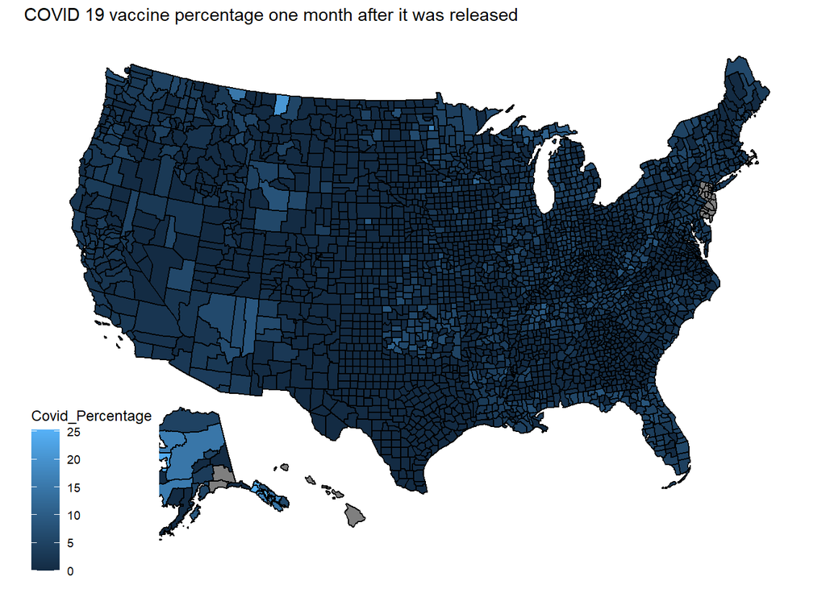

```r
plot_usmap(data = US_One_Month, values = "Covid_Percentage", "counties", color="black")+
  labs(title = "COVID 19 vaccine percentage one month after it was released")
```

Six months later a lot more people were willing to take the covid 19 vaccine while some counties and states had their reservations about taking the covid 19 vaccine leading some counties to have a zero percent vaccination rate.

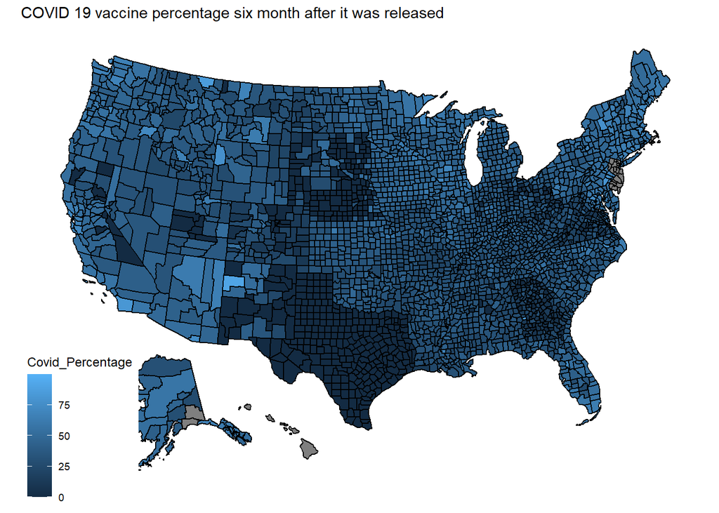

```r
plot_usmap(data = US_Six_Month, values = "Covid_Percentage", "counties", color="black")+
  labs(title = "COVID 19 vaccine percentage six month after it was released")
```

One year after the covid 19 vaccine was released and for the most part most of the counties have at least a 50 % vaccination rate but some counties are still hesitant to take the covid 19 vaccination.

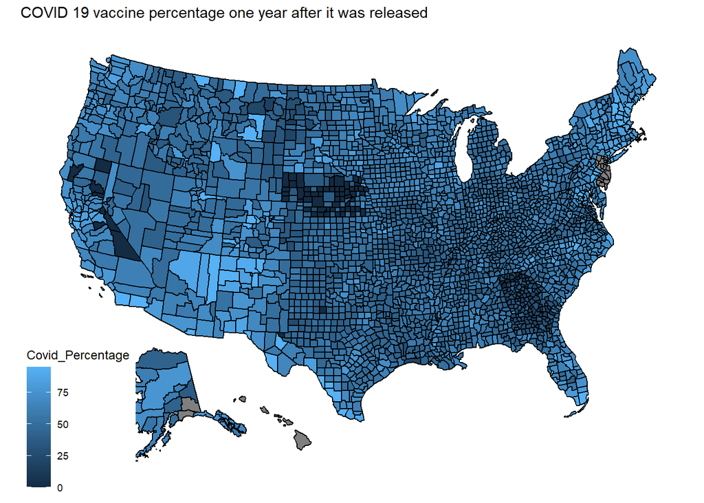

```r
plot_usmap(data = US_One_Year, values = "Covid_Percentage", "counties", color="black")+
  labs(title = "COVID 19 vaccine percentage one year after it was released")
```

# Initial Plotting

We plotted the influenza vaccine data against the 3 dates of covid vaccine data on a scatterplot and graphed a line of best fit. However, we observed that our data has far too many outliers to produce any coherent result, evident by the numerous counties with 0% or 100% covid vaccination rates.

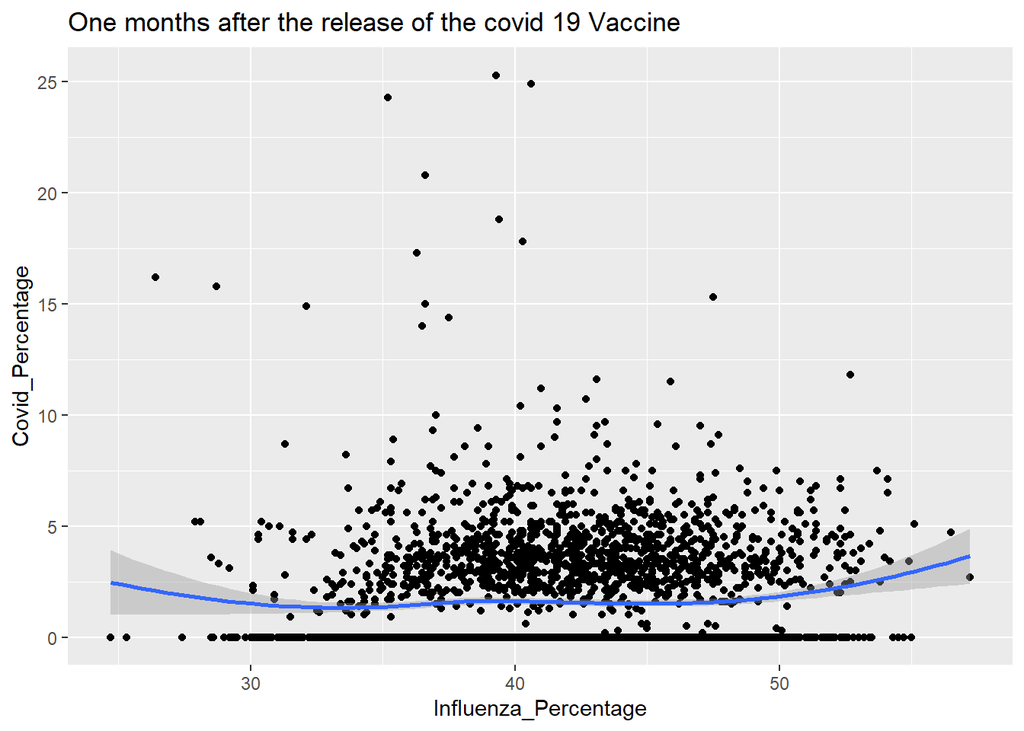

```r
#FirstMonthJoined
#SixMonthsjoined
#OneYearJoined


FirstMonthjoinedPlus %>%
        ggplot(aes(x = Influenza_Percentage, y = Covid_Percentage)) +
        geom_point()+
        labs(title = "One months after the release of the covid 19 Vaccine") +
        geom_smooth(method = "loess",
              formula = y ~ x)
```

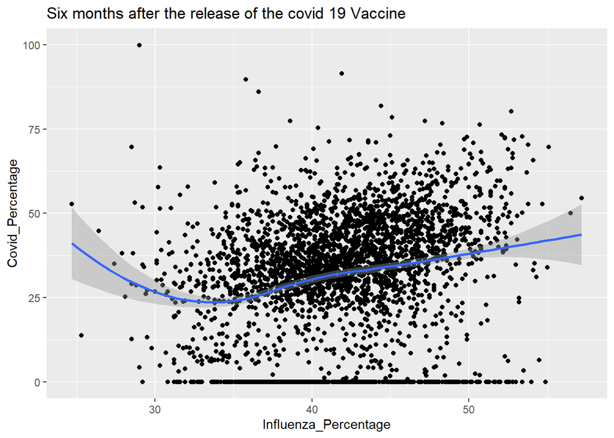

```r
 # cor(FirstMonthjoinedPlus$Influenza_Percentage, FirstMonthjoinedPlus$Covid_Percentage)


SixMonthsjoinedPlus %>%
        ggplot(aes(x = Influenza_Percentage, y = Covid_Percentage))+
        geom_point()+
        labs(title = "Six months after the release of the covid 19 Vaccine") +
        geom_smooth(method = "loess",
              formula = y ~ x)
```

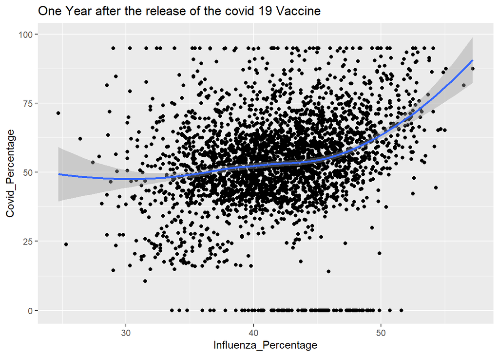

```r
##  cor(SixMonthsCors$Influenza_Percentage, SixMonthsCors$Covid_Percentage)

oneYearjoinedPlus %>%
        ggplot(aes(x = Influenza_Percentage, y = Covid_Percentage)) +
        geom_point()+
        labs(title = "One Year after the release of the covid 19 Vaccine") +
        geom_smooth(method = "loess",
              formula = y ~ x)
```

```r
#OneYearCors<- oneYearjoinedPlus%>%
  #cor(Influenza_Percentage, Covid_Percentage)
```

# Removal of Outliers

Remove counties that have less than 1000 people using the 2019 census data as they don’t have a sufficient sample size. In addition, remove counties with a 100% or 0% covid vaccination rates as these are counties that either have some special priority by the federal government or no access and are therefore unrepresentative. This results in our 3 final datasets, each with 5 columns containing FIPS (County identifier), Date, Covid_Percentage, Influenza_Percentage, and Census2019 18+ Data. Each dataframe describes a different year in which the Covid_Percentage was calculated. (Ideally we would’ve compressed our data into a single dataframe to prevent the repetition of non-covid data, however we have not done that). Each row represents a unique county. Date is in YYYY-MM-DD format. Covid and Influenza percentage are percentages without the % symbol. Census2019 Data is a numeric value describing the estimated amount of people in the county.

```r
pop_limit = 1000

OneYear <- OneYear%>%
  filter(Covid_Percentage < 100)%>%
  filter(Covid_Percentage > 1)

FirstMonthjoinedPlus_Out <- FirstMonthjoinedPlus %>%
  filter(Census2019_18PlusPop > pop_limit) %>%
  filter(Covid_Percentage < 100) %>%
  filter(Covid_Percentage > 1)

SixMonthsjoinedPlus_Out <- SixMonthsjoinedPlus %>%
  filter(Census2019_18PlusPop > pop_limit) %>%
  filter(Covid_Percentage < 100) %>%
  filter(Covid_Percentage > 1)

oneYearjoinedPlus_Out <- oneYearjoinedPlus %>%
  filter(Census2019_18PlusPop > pop_limit) %>%
  filter(Covid_Percentage < 100) %>%
  filter(Covid_Percentage > 1)

print(sample_n(FirstMonthjoinedPlus_Out,20))
```

```
##    Covid_Percentage       Date  fips Census2019_18PlusPop Influenza_Percentage
## 1               4.1 2021-01-17 36111               146629                 40.5
## 2               4.5 2021-01-17 32510                44568                 44.5
## 3               4.2 2021-01-17 20089                 2293                 46.4
## 4               3.8 2021-01-17  4023                34123                 40.4
## 5               4.6 2021-01-17 40143               488135                 45.4
## 6               2.7 2021-01-17 42133               350349                 43.5
## 7               5.4 2021-01-17 24037                86428                 43.4
## 8               3.5 2021-01-17 36075                92646                 45.6
## 9               4.3 2021-01-17 37087                50968                 51.8
## 10              3.4 2021-01-17  1033                43686                 39.2
## 11              2.1 2021-01-17 42027               138326                 44.7
## 12              2.6 2021-01-17 45073                63765                 43.0
## 13              8.7 2021-01-17 12063                37647                 31.3
## 14              3.8 2021-01-17 17053                10026                 39.2
## 15              4.7 2021-01-17 27015                19556                 42.7
## 16              3.1 2021-01-17 12055                88350                 35.3
## 17              2.9 2021-01-17 41045                22654                 34.8
## 18              3.0 2021-01-17 18071                33426                 38.6
## 19              8.7 2021-01-17 47171                14568                 43.5
## 20              3.6 2021-01-17  5051                79575                 41.7
```

# Replot data with outliers removed

After all of the data cleaning and merging our results show that there is little correlation between the percentage of people in each county who have received an influenza vaccination and the percentage of people who took the Covid COVID-19 vaccination in the first month, the sixth month, and one year after the covid 19 Vaccine was released to the general population.

After the first month, the percentage of counties that received the Covid vaccination was still relatively low. The correlation coefficient between the COVID percentage and the Influenza Percentage was -0.0352727391909994 which is a low correlation value meaning that in the first month, the percentage of influenza vaccination and the percentage of COVID-19 vaccination have a low correlation with each other.

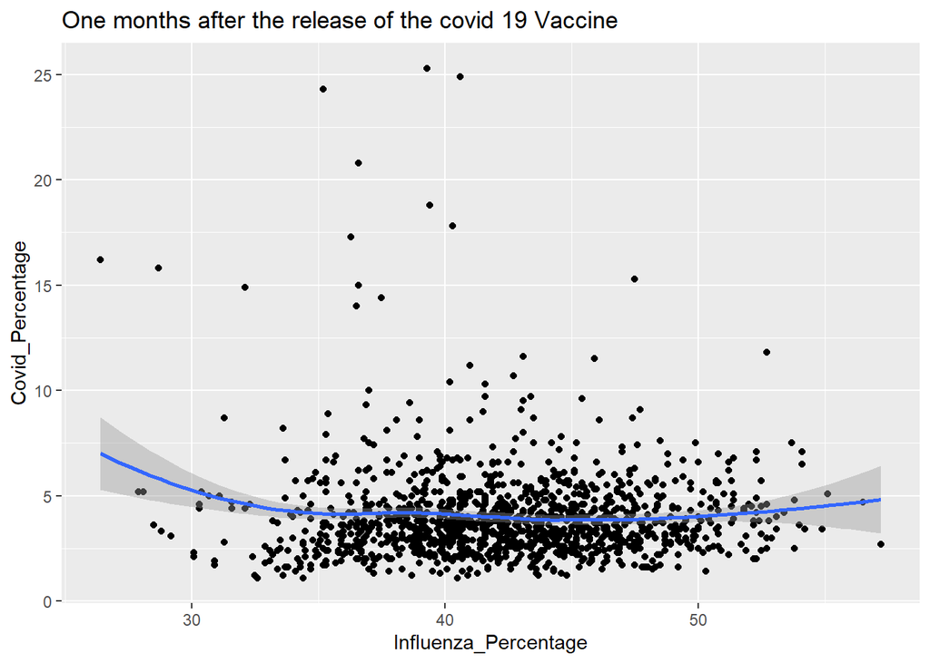

```r
FirstMonthjoinedPlus_Out %>%
        ggplot(aes(x = Influenza_Percentage, y = Covid_Percentage)) +
        geom_point()+
        labs(title = "One months after the release of the covid 19 Vaccine") +
        geom_smooth(method = "loess",
              formula = y ~ x)
```

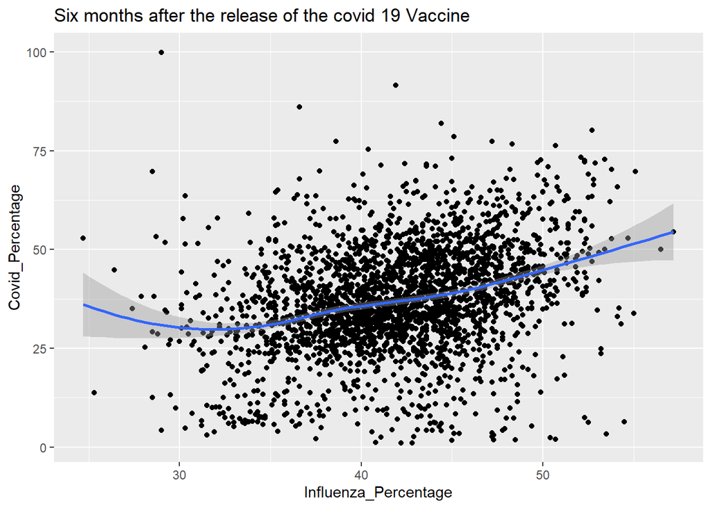

```r
SixMonthsjoinedPlus_Out %>%
        ggplot(aes(x = Influenza_Percentage, y = Covid_Percentage))+
        geom_point()+
        labs(title = "Six months after the release of the covid 19 Vaccine") +
        geom_smooth(method = "loess",
              formula = y ~ x)
```

One year after the COVID-19 vaccine was released the increase in the percentage of counties that were vaccinated. In this scatter plot, there are still outliers now at the very top as well because in this Data set, we focussed on the counties and some counties have extremely small populations which leads to points bunching off at the very top of the graph. The correlation coefficient for one year since the release of the Covid 19 vaccine was 0.34957725497233 Comparing the jump from one month to six months the jump from 6 months to one year doesn’t add any substantial evidence for us to conclude that there was any correlation between a person’s willingness to take the Covid 19 vaccine compared to the influenza vaccine.

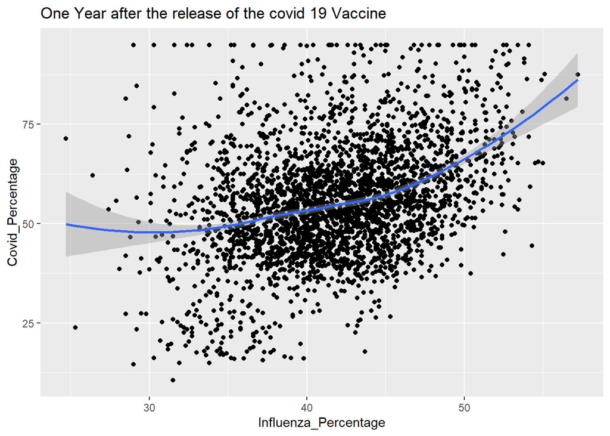

```r
oneYearjoinedPlus_Out %>%
        ggplot(aes(x = Influenza_Percentage, y = Covid_Percentage)) +
        geom_point()+
        labs(title = "One Year after the release of the covid 19 Vaccine") +
        geom_smooth(method = "loess",
              formula = y ~ x)
```

# Calculating correlation coefficient

The correlation is nearly nonexistent in the first month (likely due to lack of availability), however it grows quickly. This trend may continue into later years, however our study only goes one year in. This is likely due to vaccine availability, although it may represent how the willingness to take the covid vaccine was less related to vaccine willingness in general and more of various other factors like public mistrust in the safety of a vaccine produced so quickly. The correlation coefficient however never reaches a value of 0.5 or above, so the correlation isn’t strong enough to substantiate our hypothesis regarding covid vaccine willingness.

```r
firstMonthCor <- cor(FirstMonthjoinedPlus_Out$Influenza_Percentage, FirstMonthjoinedPlus_Out$Covid_Percentage, use='complete.obs')
paste("First month correlation coefficent", firstMonthCor)
```

```
## [1] "First month correlation coefficent -0.0352727391909994"
```

```r
SixMonthsCor <- cor(SixMonthsjoinedPlus_Out$Influenza_Percentage, SixMonthsjoinedPlus_Out$Covid_Percentage, use='complete.obs')
paste("Six month correlation coefficent", SixMonthsCor)
```

```
## [1] "Six month correlation coefficent 0.309864523848093"
```

```r
oneYearCor <- cor(oneYearjoinedPlus_Out$Influenza_Percentage, oneYearjoinedPlus_Out$Covid_Percentage,  use='complete.obs')
paste("One year correlation coefficent", oneYearCor)
```

```
## [1] "One year correlation coefficent 0.34957725497233"
```

# Findings and summary

After all of the data cleaning and merging our results show that there is little correlation between the percentage of people in each county who have received an influenza vaccination and the percentage of people who took the Covid COVID-19 vaccination in the first month, the sixth month, and one year after the covid 19 Vaccine was released to the general population.

After the first month, the percentage of counties that received the Covid vaccination was still relatively low. The correlation coefficient between the COVID percentage and the Influenza Percentage was -0.0352727391909994 which is a low correlation value meaning that in the first month, the percentage of influenza vaccination and the percentage of COVID-19 vaccination have a low correlation with each other.

One year after the COVID-19 vaccine was released the increase in the percentage of counties that were vaccinated. In this scatter plot, there are still outliers now at the very top as well because in this Data set, we focussed on the counties and some counties have extremely small populations which leads to points bunching off at the very top of the graph. The correlation coefficient for one year since the release of the Covid 19 vaccine was 0.34957725497233 Comparing the jump from one month to six months the jump from 6 months to one year doesn’t add any substantial evidence for us to conclude that there was any correlation between a person’s willingness to take the Covid 19 vaccine compared to the influenza vaccine.

# Background

### Why do you use these datasets?

The datasets for our research were chosen carefully to ensure their credibility, reliability, and alignment with our objectives. The Centers for Disease Control and Prevention (CDC) is a globally recognized authority in public health, and their data provides unparalleled credibility. The meticulousness of the CDC’s data collection processes assures the accuracy and validity of the information.

Our research focuses on the correlation between influenza and COVID-19 vaccination rates, and the datasets we selected are precise in this regard. These datasets cover diverse geographic locations, making them even more significant. We can comprehensively analyze vaccination patterns by incorporating data from various regions and demographic landscapes. This inclusivity enriches our findings, ensuring that our insights are relevant and representative of different states and counties.

### Where do your datasets originate from? (4 points)

The research project relies on datasets primarily sourced from the Centers for Disease Control and Prevention (CDC), which is a leading public health institute in the United States. Our influenza vaccination data comes from the CDC dataset called “Influenza Vaccination Coverage for All Ages,” while the COVID-19 vaccination data comes from the CDC dataset known as “COVID-19 Vaccinations in the United States by County.”

These datasets are highly trustworthy as they come from a reputable institution such as the CDC. We can rely on their accuracy and reliability as the CDC is a trusted authority in the field of public health. By using these datasets, we gain access to a wealth of information that is representative of the CDC’s extensive efforts in monitoring and reporting on vaccination trends. The “Influenza Vaccination Coverage for All Ages” dataset provides insights into influenza vaccination rates across various age groups. Meanwhile, the “COVID-19 Vaccinations in the United States by County” dataset allows for a detailed analysis of COVID-19 vaccination rates at the county level, providing a nuanced perspective on regional disparities.

The reason for selecting these CDC datasets is to understand the relationship between influenza and COVID-19 vaccination rates. We have deliberately chosen datasets that are renowned for their accuracy and coverage, encompassing a wide range of demographic and geographic nuances.

### Who collected data?

The Centers for Disease Control and Prevention (CDC) is a highly respected national public health institute in the United States that plays a crucial role in collecting and maintaining datasets. The CDC’s unwavering commitment to the highest standards of data collection ensures the dependability and credibility of the information.

As an authority in public health, the CDC’s meticulous approach to data collection not only guarantees the accuracy of the information, but also inspires confidence in the comprehensiveness of the dataset. The Institute’s adherence to rigorous processes and protocols is a testament to its dedication to transparency and precision in disseminating health-related information.

In summary, the CDC’s responsibility in curating and maintaining these datasets makes them invaluable resources for research and analysis. The dataset’s reliability is further enhanced by the CDC’s reputation for excellence and commitment to safeguarding the nation’s health. Therefore, the dataset serves as a reliable cornerstone for research endeavors and significantly contributes to the robustness and credibility of the findings.The Centers for Disease Control and Prevention (CDC) is a highly respected national public health institute in the United States that plays a crucial role in collecting and maintaining datasets. The CDC’s unwavering commitment to the highest standards of data collection ensures the dependability and credibility of the information.

# Data usage permissions

Both datasets are available to the public on the CDC’s official data portal, and as of the most recent update in January 2022, there are no explicit restrictions on data usage. This means that researchers, policymakers, and the general public are free to use the information for various purposes. While it’s important to be aware of any possible changes to the usage policies, the current openness of the data enhances its value for a wide range of applications.

### What are the datasets about? What is the population and what is the sample?

The influenza vaccine dataset contains information on influenza vaccination coverage for individuals aged 6 months and older, covering all age groups. It represents a diverse population across various states and counties in the United States. Similarly, the COVID-19 vaccine dataset focuses on vaccination rates at the county level, encompassing the entire population. This provides a detailed overview of COVID-19 immunization efforts across different regions. Both datasets offer a comprehensive perspective on vaccination coverage and patterns within the specified populations.

### Discuss any data quality issues you encountered

The datasets provided by the CDC are usually dependable, but there may be some data quality issues that could arise. These could include gaps in the influenza dataset or differences in reporting practices across various counties. It’s crucial to give careful attention to these problems and document any missing or inconsistent data during the analysis process. Additionally, the timeliness of the reporting can impact data quality, as vaccination rates may change over time. To mitigate these issues, it’s essential to regularly update and cross-validate with other reputable sources, which can enhance the overall robustness and reliability of the analysis.

# References

AJMC Staff. (2021, June 3). A Timeline of COVID-19 Vaccine Developments in 2021. AJMC. https://www.ajmc.com/view/a-timeline-of-covid-19-vaccine-developments-in-2021 Cohen, S. (2020, December 10). The Fastest Vaccine in History. Www.uclahealth.org. https://www.uclahealth.org/news/the-fastest-vaccine-in-history Commissioner, O. of the. (2021, August 23). FDA Approves First COVID-19 Vaccine. FDA. https://www.fda.gov/news-events/press-announcements/fda-approves-first-covid-19-vaccine#:~:text=Today%2C%20the%20U.S.%20Food%20and COVID Vaccine Testing and Approval. (2022, September 29). Www.umms.org. https://www.umms.org/coronavirus/covid-vaccine/testing History of influenza vaccination. (n.d.). Www.who.int. https://www.who.int/news-room/spotlight/history-of-vaccination/history-of-influenza-vaccination#:~:text=The%20vaccine%20was%20tested%20for Understanding the COVID Vaccine and mRNA. (n.d.). Www.umms.org. https://www.umms.org/coronavirus/covid-vaccine/mrna#:~:text=The%20use%20of%20mRNA%20technology

# Final Dataset

```r
save(FirstMonthjoinedPlus_Out, file = "final_datasets/FirstMonthjoinedPlus_Out.RData")
save(SixMonthsjoinedPlus_Out, file = "final_datasets/SixMonthsjoinedPlus_Out.RData")
save(oneYearjoinedPlus_Out, file = "final_datasets/oneYearjoinedPlus_Out.RData")
```